# Time series regression studies in environmental epidemiology

Báo cáo tái lập nghiên cứu

Nhóm 1 - Thạc sĩ Y học dự phóng

22/11/2026

## 1. Mục tiêu & Thiết kế nghiên cứu

**Mục tiêu nghiên cứu**

- Trình bày phương pháp luận và hướng dẫn sử dụng **hồi quy chuỗi thời gian** trong dịch tễ học môi trường.
- **Câu hỏi nghiên cứu:** Biến động nồng độ **ozone** hằng ngày có liên quan đến nguy cơ **tử vong** ngắn hạn hằng ngày hay không?

**Thiết kế nghiên cứu**

- **Nghiên cứu chuỗi thời gian** (*time series regression*).
- **Đơn vị thời gian:** Ngày lịch.
- **Biến nhiễu:** Chỉ các yếu tố *biến thiên theo ngày* liên quan cả phơi nhiễm và kết cục (nhiệt độ, độ ẩm).

> **Điểm quan trọng:** Các yếu tố cá nhân (tuổi, giới, BMI, hút thuốc) **không gây nhiễu** vì không dao động theo ngày theo nồng độ ô nhiễm.

## 2. Phương pháp nghiên cứu & Bộ dữ liệu

1.826

Ngày quan sát liên tục (2002–2006)

0%

Tỷ lệ dữ liệu khuyết (Missing)

149,5

Ca tử vong TB / ngày

34,8

Ozone TB ngày (µg/m³)

**Bộ dữ liệu `londondataset2002_2006.dta`**

4 chuỗi thời gian hàng ngày (01/01/2002 – 31/12/2006):

1. `ozone` ($\mu\text{g/m}^3$) — Phơi nhiễm chính
2. `numdeaths` (ca/ngày) — Kết cục chính
3. `temperature` (°C)
4. `relative_humidity` (%)

**Quy trình nghiên cứu 4 bước**

1. Mô tả chuỗi thời gian & tương quan sơ bộ.
2. Kiểm soát mùa vụ & xu hướng dài hạn (3 phương pháp).
3. Ước lượng phơi nhiễm – kết cục & kiểm soát nhiễu nhiệt độ.
4. Mô hình hóa hiệu ứng trễ (Lag 0–7 ngày).

## 3. Phương pháp phân tích dữ liệu

$$\log\big(E[Y_t]\big) = \alpha + \beta \cdot \text{Ozone}_{t} + s(t) + f(\text{Temp}_t)$$

**Hồi quy Quasi-Poisson & Kiểm soát thời gian**

- Xử lý biến kết cục dạng đếm có **quá phân tán (overdispersion)** bằng tham số tỷ lệ $\hat{\phi} = \chi^2_{\text{Pearson}}/\text{df}$.
- So sánh 3 hàm kiểm soát mùa vụ & xu hướng $s(t)$:
  - Phân tầng theo tháng lịch ($12 \times 5 = 60$ tầng).
  - Chuỗi Fourier (4 cặp sin/cos + xu hướng tuyến tính).
  - **Cubic B-spline** (`df = 35`, ~7 bậc tự do/năm).

**Nhiệt độ phi tuyến & Hiệu ứng trễ (`dlnm`)**

- Nhiệt độ chia **10 tầng phân vị (deciles)** để nắm bắt quan hệ phi tuyến.
- Mở rộng sang cửa sổ trễ **0–7 ngày**:
  - *Single-lag:* Chạy riêng từng độ trễ $l = 0, \dots, 7$.
  - *Unconstrained DLM:* Đưa đồng thời cả 8 độ trễ.
  - *Constrained DLM:* Ràng buộc phân tầng (lag 1–2 bằng nhau; lag 3–7 bằng nhau) để giảm đa cộng tuyến.

# 4. Kết quả và Nhận định

## Table 1: Cấu trúc 12 dòng dữ liệu đầu tiên

| Ngày | Ozone (µg/m³) | Nhiệt độ (°C) | Độ ẩm (%) | Tử vong (ca) |
| --- | --- | --- | --- | --- |
| 01 Jan 2002 | 4.59 | -0.2 | 75.7 | 199 |
| 02 Jan 2002 | 4.88 | 0.1 | 77.5 | 231 |
| 03 Jan 2002 | 4.71 | 0.9 | 81.3 | 210 |
| 04 Jan 2002 | 4.14 | 0.5 | 85.4 | 203 |
| 05 Jan 2002 | 2.01 | 4.2 | 93.5 | 224 |
| 06 Jan 2002 | 2.40 | 7.1 | 96.4 | 198 |
| 07 Jan 2002 | 4.08 | 5.2 | 93.5 | 180 |
| 08 Jan 2002 | 3.13 | 3.5 | 81.5 | 188 |
| 09 Jan 2002 | 2.05 | 3.2 | 88.3 | 168 |
| 10 Jan 2002 | 5.19 | 5.3 | 85.4 | 194 |
| 11 Jan 2002 | 3.59 | 3.0 | 92.6 | 223 |
| 12 Jan 2002 | 12.87 | 4.8 | 94.2 | 201 |

- Mỗi dòng biểu diễn **1 ngày quan sát liên tiếp**, đầy đủ cả 4 chuỗi thời gian.
- Đầu tháng 1/2002 (mùa đông): nhiệt độ lạnh ($-0.2^\circ\text{C}$ đến $7.1^\circ\text{C}$), nồng độ ozone thấp (chủ yếu $< 5.2~\mu\text{g/m}^3$), nhưng tử vong ở mức cao (**168–231 ca/ngày**).
- Gợi ý ban đầu về hiện tượng ngược pha theo mùa.

## Figure 1: Diễn biến chuỗi thời gian dữ liệu thô

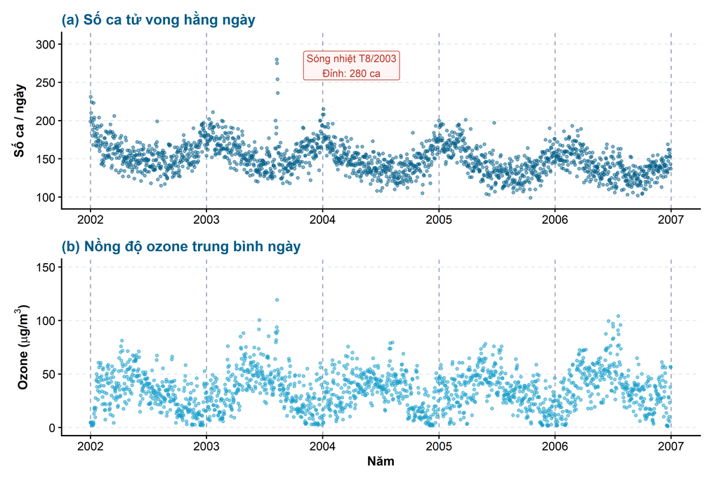

- **Ngược pha mùa vụ:** Tử vong cao mùa đông / thấp mùa hè; ozone cao mùa hè / thấp mùa đông.
- Tương quan âm ($r = -0.123$) nhưng **không thể suy diễn nhân quả**.
- Ozone tương quan dương với nhiệt độ ($r = 0.456$).
- Ghi nhận đỉnh sóng nhiệt tháng 8/2003 (280 ca tử vong/ngày).

## Figure 2: Kiểm soát mùa vụ và xu hướng dài hạn

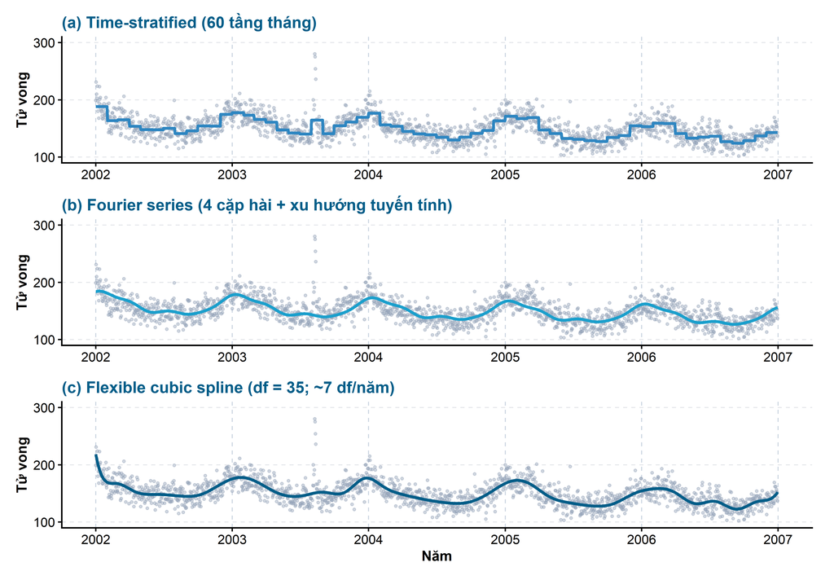

**So sánh 3 phương pháp**

- **(a) Phân tầng tháng:** Dễ hiểu nhưng tạo bước nhảy nguy cơ phi sinh học giữa các tháng, nhiều tham số.
- **(b) Chuỗi Fourier:** Mượt, ít tham số nhưng ép hình dạng sóng mùa giống hệt nhau qua các năm.
- **(c) Cubic spline (Tối ưu):** Mượt, cho phép chu kỳ mùa thay đổi linh hoạt từng năm và bắt đồng thời xu hướng dài hạn.

## Figure 3: Phần dư sau loại bỏ mùa vụ & xu hướng

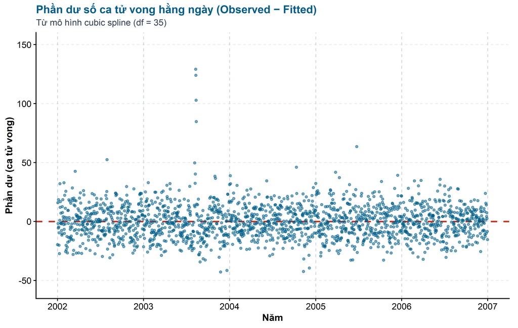

- Toàn bộ quy luật mùa vụ và xu hướng dài hạn đã được loại bỏ hoàn toàn; phần dư dao động đối xứng quanh $0$.
- Phần biến thiên ngắn hạn còn lại là cơ sở kiểm định vai trò của ozone từng ngày.
- Các đỉnh phần dư dương (> 80–130 ca) tháng 8/2003 nhấn mạnh nhu cầu hiệu chỉnh **nhiệt độ**.

## Hiệu chỉnh nhiễu Ozone – Tử vong tại Lag 0

| Mô hình (Lag 0) | RR (mỗi +10 µg/m³) | 95% CI | Thay đổi nguy cơ (%) | Giá trị P |
| --- | --- | --- | --- | --- |
| Mô hình Poisson thô (Chưa hiệu chỉnh) | 0.991 | 0.987 – 0.994 | -0.93% | < 0.001 |
| Mô hình + Mùa vụ & xu hướng (Cubic spline) | 1.007 | 1.003 – 1.010 | +0.66% | < 0.001 |
| Mô hình + Nhiệt độ cùng ngày (Thập phân vị) | 1.003 | 0.999 – 1.006 | +0.27% | 0.107 |

**1. Đảo chiều do nhiễu mùa vụ (M4 $\rightarrow$ M5)**

- Mô hình thô cho kết quả âm tính giả tạo ($\text{RR} = 0.991$).
- Sau hiệu chỉnh mùa vụ/xu hướng, ozone liên quan dương tính rõ rệt: tăng **0.7%** nguy cơ tử vong mỗi $+10~\mu\text{g/m}^3$ ($p < 0.001$).

**2. Nhiễu do nhiệt độ cùng ngày (M5 $\rightarrow$ M6)**

- Bổ sung nhiệt độ phi tuyến làm ước lượng tiến về 1 ($\text{RR} = 1.003$, $p = 0.11$) và **không còn ý nghĩa thống kê**. $\Rightarrow$ Tác động ozone *cùng ngày* chủ yếu do nhiệt độ gây nhiễu!

## Figure 4: Mô hình hóa hiệu ứng trễ (Lag 0–7 ngày)

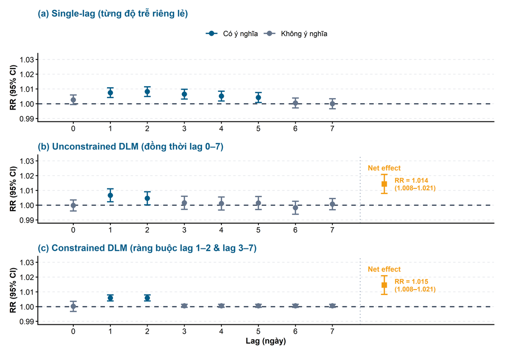

- **(a) Single-lag:** Có ý nghĩa thống kê từ lag 1–5 nhưng bị **nhiễu lẫn nhau** giữa các ngày liền kề.
- **(b) Unconstrained DLM:** Chỉ còn tác động độc lập tại **lag 1 ($\text{RR}=1.007$)** và **lag 2 ($\text{RR}=1.005$)**.
- **(c) Constrained DLM:** Giảm đa cộng tuyến, thu hẹp 95% CI từng lag rõ rệt.
- **Net effect (0–7 ngày):** $\text{RR} = 1.014$ (95% CI: 1.008–1.021), ổn định giữa cả hai mô hình DLM; không thấy hiện tượng mùa vụa rõ rệt.

## 5. Kết luận chính

**Phát hiện từ bộ dữ liệu London (2002–2006)**

- Kiểm soát mùa vụ/xu hướng đảo ngược ước lượng ozone từ âm tính giả tạo ($0.991$) sang dương tính ($1.007$).
- Nhiệt độ giải thích phần lớn tác động ozone cùng ngày ($\text{RR}_{\text{lag 0}} = 1.003, p = 0.11$).
- **Tác động trễ độc lập rõ rệt tại lag 1–2 ngày**, với hiệu ứng cộng dồn 0–7 ngày là **$\text{RR} = 1.014$** (tăng 1.44% nguy cơ tử vong mỗi $+10~\mu\text{g/m}^3$ ozone).

**Bài học phương pháp luận**

- Hồi quy chuỗi thời gian giải quyết 4 thách thức đặc thù: **mùa vụ/xu hướng dài hạn**, **hiệu ứng trễ & đa cộng tuyến**, **quan hệ phi tuyến**, và **quá phân tán / tự tương quan**.
- Quy trình cốt lõi vẫn đồng nhất với dịch tễ học kinh điển: khám phá dữ liệu $\rightarrow$ kiểm soát nhiễu có cơ sở sinh học $\rightarrow$ trình bày ước lượng chuẩn $\rightarrow$ chẩn đoán và phân tích độ nhạy.